# Reproducible data assessment

## Loading and preprocessing the data

```r
library(dplyr)
file <- "C:/Coursera/repdata/activity.csv"
data <- read.csv(file, header = TRUE, sep = ",")
```

## What is mean total number of steps taken per day?

### 1. Histogram of total number of steps taken each day

```r
activity_stepsday <-aggregate(steps ~ date,  data, sum, na.rm = TRUE)
```

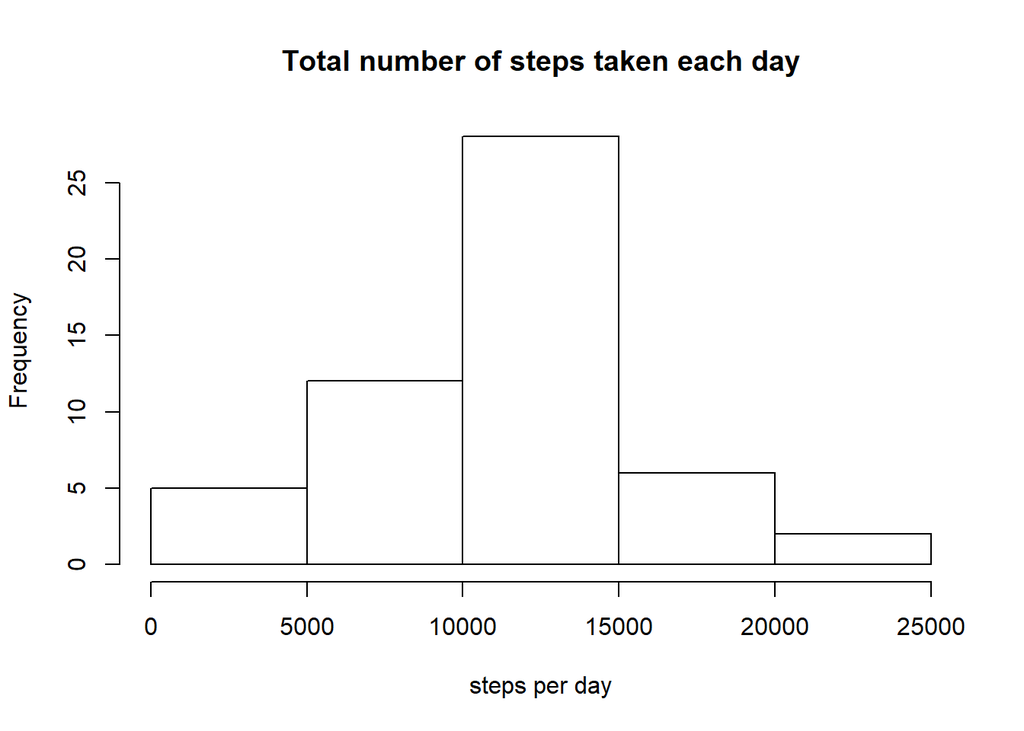

```r
hist(activity_stepsday$steps, xlab = "steps per day", main = "Total number of steps taken each day")
```

### 2. Calculate and report the mean and median total number of steps taken per day

```r
mean(activity_stepsday$steps)
```

```
## [1] 10766.19
```

```r
median(activity_stepsday$steps)
```

```
## [1] 10765
```

## What is the average daily activity pattern?

### 1. Make a time series plot (i.e. type = “l”) of the 5-minute interval (x-axis) and the average number of steps taken, averaged across all days (y-axis)

```r
activity_interval <-aggregate(steps ~ interval,  data, mean, na.rm = TRUE)
```

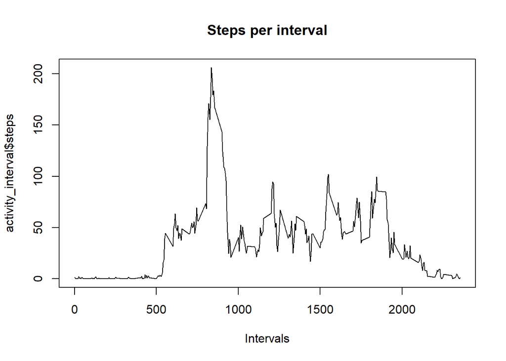

```r
plot(activity_interval$interval, activity_interval$steps, type = "l", xlab = "Intervals", main = "Steps per interval")
```

### 2. Which 5-minute interval, on average across all the days in the dataset, contains the maximum number of steps?

```r
maximum <- max(activity_interval$steps)
max_steps <- filter(activity_interval, activity_interval$steps == maximum)
max_steps
```

```
##   interval    steps
## 1      835 206.1698
```

## Imputing missing values

### 1. Calculate and report the total number of missing values in the dataset (i.e. the total number of rows with NAs)

```r
sum(is.na(data))
```

```
## [1] 2304
```

### 2. Devise a strategy for filling in all of the missing values in the dataset. The strategy does not need to be sophisticated. For example, you could use the mean/median for that day, or the mean for that 5-minute interval, etc.

Overall average strategy:

```r
activity_daymean <-aggregate(steps ~ date,  data, mean, na.rm = TRUE)
head(activity_daymean)
```

```
##         date    steps
## 1 2012-10-02  0.43750
## 2 2012-10-03 39.41667
## 3 2012-10-04 42.06944
## 4 2012-10-05 46.15972
## 5 2012-10-06 53.54167
## 6 2012-10-07 38.24653
```

### 3. Create a new dataset that is equal to the original dataset but with the missing data filled in.

```r
dataNA <- data
dataNA$steps[which(is.na(dataNA$steps))] <- mean(dataNA$steps, na.rm = TRUE)
```

```r
dataNA_perday <- aggregate(steps ~ date, dataNA, sum, na.rm = TRUE)
mean(activity_stepsday$steps)
```

```
## [1] 10766.19
```

```r
median(activity_stepsday$steps)
```

```
## [1] 10765
```

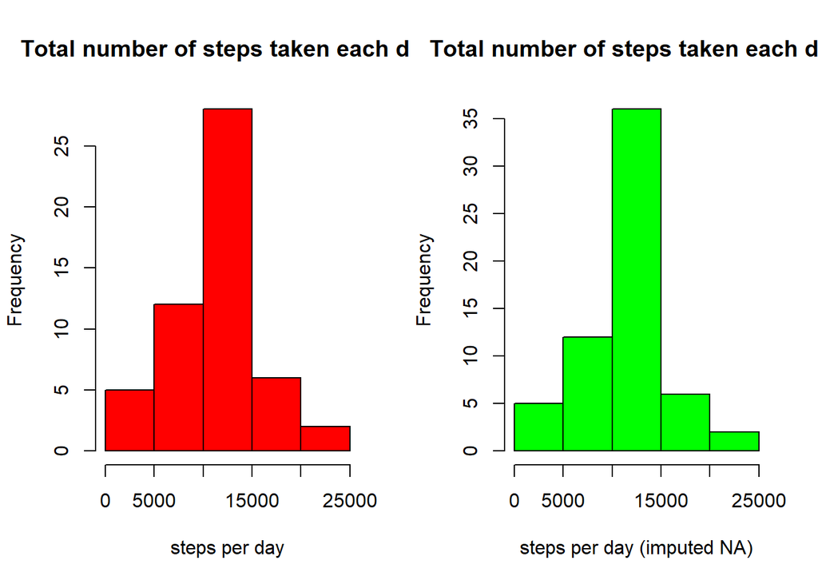

```r
par(mfrow = c(1,2))
hist(activity_stepsday$steps, xlab = "steps per day", main = "Total number of steps taken each day", col = "red")
hist(dataNA_perday$steps, xlab = "steps per day (imputed NA)", main = "Total number of steps taken each day", col = "green")
```

## Are there differences in activity patterns between weekdays and weekends?

### Create a new factor variable in the dataset with two levels - “weekday” and “weekend” indicating whether a given date is a weekday or weekend day.

```r
dataNAdate <- as.POSIXct(dataNA$date)
dataNA$date <- dataNAdate
dataNA <- mutate(dataNA, weekdays = "")
dataNA$weekdays <- ifelse( weekdays(dataNA$date) == "sábado" | weekdays(dataNA$date) == "domingo", "weekend", "weekday")
dataNA$weekdays <- factor(dataNA$weekdays)
str(dataNA)
```

```
## 'data.frame':    17568 obs. of  4 variables:
##  $ steps   : num  37.4 37.4 37.4 37.4 37.4 ...
##  $ date    : POSIXct, format: "2012-10-01" "2012-10-01" ...
##  $ interval: int  0 5 10 15 20 25 30 35 40 45 ...
##  $ weekdays: Factor w/ 2 levels "weekday","weekend": 1 1 1 1 1 1 1 1 1 1 ...
```

### Make a panel plot containing a time series plot (i.e. type=“l”) of the 5-minute interval (x-axis) and the average number of steps taken, averaged across all weekday days or weekend days (y-axis). See the README file in the GitHub repository to see an example of what this plot should look like using simulated data.

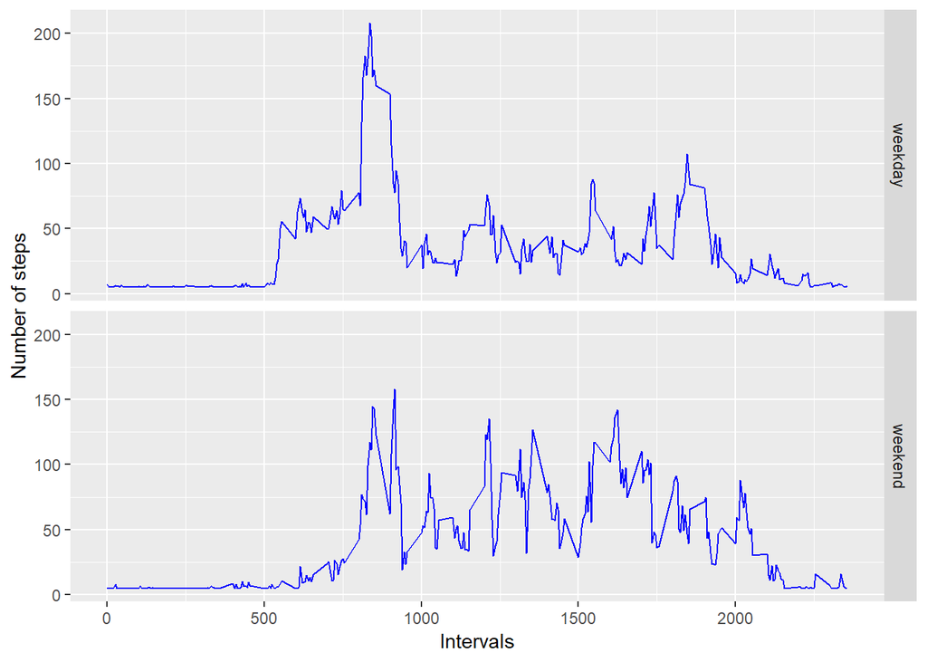

```r
steps_interval_weekday <- aggregate(steps ~ interval + weekdays, dataNA, mean)
#ggplot2
library(ggplot2)
g <- ggplot(steps_interval_weekday, aes(interval, steps))
g + geom_line(color = "blue") + facet_grid(weekdays~.) + labs(x = "Intervals", y ="Number of steps")
```